# 전자산업데이터분석 기말 PROJECT

## 지역별 분석

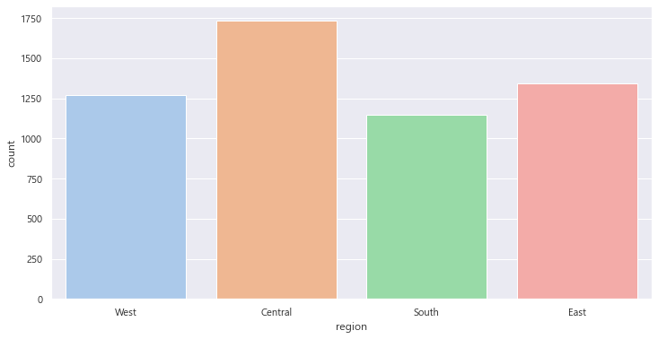

```python
plt.figure(figsize=(12,6))
sns.countplot(EW_df.region);
```

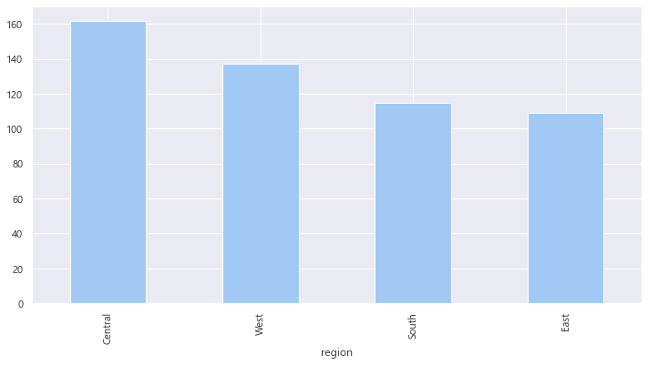

```python
EW_df.query("order_status == 'returned'").groupby('region').record_id.count().sort_values(ascending=False).plot(figsize=(12,6), kind='bar');
```

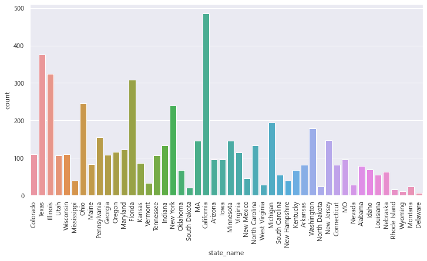

```python
plt.figure(figsize=(12,6))
sns.countplot(EW_df.state_name)
plt.xticks(rotation=90);
```

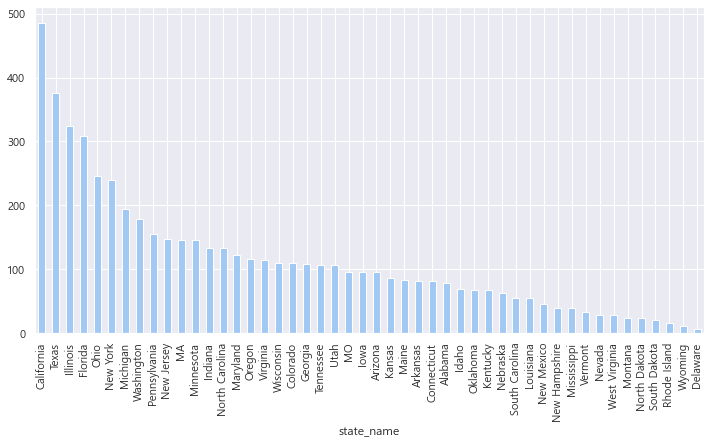

```python
EW_df.groupby('state_name').record_id.count().sort_values(ascending=False).plot(figsize=(12,6), kind='bar');
```

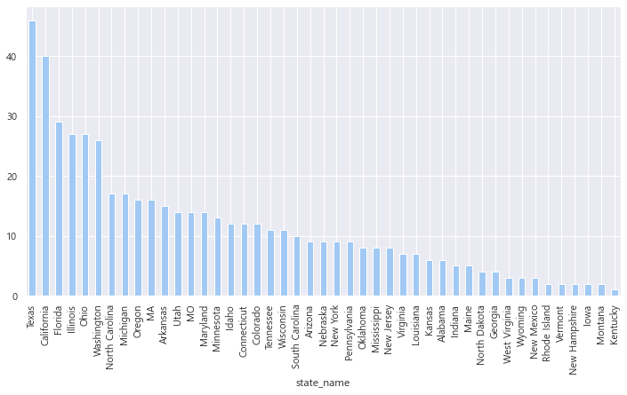

```python
EW_df.query("order_status == 'returned'").groupby('state_name').record_id.count().sort_values(ascending=False).plot(figsize=(12,6), kind='bar');
plt.xticks(rotation=90);
```

```python
EW_df.query("order_status == 'returned'").groupby(['customer_segment', 'state_name']).record_id.count().sort_values(ascending=False)
```

```
customer_segment  state_name
Corporate         Texas         26
Home Office       California    15
                  Illinois      13
Corporate         Ohio          13
                  Minnesota     12
                                ..
Small Business    Kansas         1
Home Office       Idaho          1
Consumer          Tennessee      1
Home Office       Iowa           1
Small Business    Wyoming        1
Name: record_id, Length: 136, dtype: int64
```

```python
EW_df.query("order_status == 'returned'").groupby(['state_name', 'product_sub_category']).order_quantity.sum().sort_values(ascending=False).iloc[:10]
```

```
state_name  product_sub_category
Ohio        Office Furnishings                230
Texas       Chairs & Chairmats                159
            Computer Peripherals              156
Washington  Paper                             154
California  Binders and Binder Accessories    151
Texas       Office Furnishings                147
            Pens & Art Supplies               144
California  Paper                             140
MA          Binders and Binder Accessories    134
Washington  Binders and Binder Accessories    129
Name: order_quantity, dtype: int64
```

```python
EW_df.groupby(['state_name', 'ship_mode']).ship_cost.count().sort_values(ascending=False)
```

```
state_name      ship_mode
California      Regular Air       362
Texas           Regular Air       288
Illinois        Regular Air       239
Florida         Regular Air       237
Ohio            Regular Air       199
                                 ...
Wyoming         Express Air         1
North Dakota    Delivery Truck      1
South Dakota    Express Air         1
North Dakota    Express Air         1
South Carolina  Delivery Truck      1
Name: ship_cost, Length: 142, dtype: int64
```

```python
EW_df.groupby('ship_mode').ship_cost.mean()
```

```
ship_mode
Delivery Truck    45.288828
Express Air        7.935491
Regular Air        7.734736
Name: ship_cost, dtype: float64
```

```python
EW_df.query("order_status == 'returned'").groupby(['state_name', 'order_priority']).order_quantity.sum().sort_values(ascending=False).iloc[:10]
```

```
state_name  order_priority
Texas       low               515
Florida     low               468
Texas       medium            376
California  low               375
            high              311
Illinois    low               306
Ohio        critical          274
Texas       critical          266
Illinois    critical          262
California  critical          256
Name: order_quantity, dtype: int64
```

```python
EW_df.groupby('state_name').lead_time.mean().sort_values(ascending=False)
```

```
state_name
Wyoming           2.818182
Minnesota         2.600000
Arizona           2.458333
California        2.405350
New York          2.350000
Indiana           2.305970
Kansas            2.298851
Maine             2.289157
Connecticut       2.283951
South Dakota      2.190476
Texas             2.186667
New Hampshire     2.175000
Oregon            2.155172
Louisiana         2.145455
Alabama           2.139241
Georgia           2.129630
Rhode Island      2.125000
Montana           2.125000
Florida           2.116883
Ohio              2.113821
Idaho             2.086957
Wisconsin         2.081818
Washington        2.072626
Nevada            2.068966
MA                1.979452
Illinois          1.978395
New Jersey        1.959184
Utah              1.943396
Virginia          1.938596
MO                1.937500
Tennessee         1.925234
Mississippi       1.925000
Nebraska          1.920635
Arkansas          1.914634
Colorado          1.909091
New Mexico        1.891304
Maryland          1.852459
Iowa              1.843750
Pennsylvania      1.832258
North Carolina    1.813433
Kentucky          1.805970
Michigan          1.800000
North Dakota      1.782609
Oklahoma          1.761194
South Carolina    1.618182
Vermont           1.515152
West Virginia     1.464286
Delaware          0.666667
Name: lead_time, dtype: float64
```

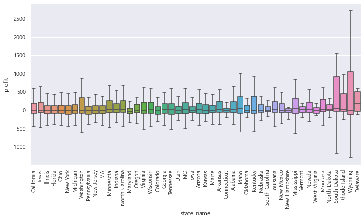

```python
X_order = EW_df.groupby('state_name').profit.count().sort_values(ascending=False).index

plt.figure(figsize=(12,6))
sns.boxplot(data=EW_df, x='state_name', y='profit', showfliers=False, order=X_order)
plt.xticks(rotation=90)
plt.show()
```

```python
(EW_df.query("order_status == 'returned'").groupby('state_name').record_id.count() / EW_df.groupby('state_name').record_id.count()).sort_values(ascending=False).round(2).iloc[:10]
```

```
state_name
Wyoming           0.27
Mississippi       0.20
Arkansas          0.18
South Carolina    0.18
Idaho             0.17
North Dakota      0.17
Connecticut       0.15
MO                0.15
Washington        0.15
Nebraska          0.14
Name: record_id, dtype: float64
```

## Ship cost 분석

```python
EW_df.groupby(['order_priority','ship_mode']).ship_cost.mean().sort_values(ascending=False)
```

```
order_priority  ship_mode
critical        Delivery Truck    47.485971
medium          Delivery Truck    45.082952
low             Delivery Truck    44.877834
high            Delivery Truck    43.935597
medium          Express Air        8.716480
low             Regular Air        8.240573
critical        Express Air        8.224931
low             Express Air        7.938400
critical        Regular Air        7.719575
medium          Regular Air        7.567839
high            Regular Air        7.355554
                Express Air        7.024526
Name: ship_cost, dtype: float64
```

```python
EW_df.groupby(['order_priority','product_container']).ship_cost.mean().sort_values(ascending=False)
```

```
order_priority  product_container
low             Jumbo Box            52.456426
critical        Jumbo Box            51.120429
high            Jumbo Box            50.443943
medium          Jumbo Box            47.746857
critical        Jumbo Drum           44.131088
medium          Jumbo Drum           42.735429
low             Jumbo Drum           38.361439
high            Jumbo Drum           37.743906
medium          Large Box            30.933909
low             Large Box            30.918146
critical        Large Box            30.722056
high            Large Box            28.754077
medium          Medium Box           14.117947
low             Medium Box           13.480857
critical        Medium Box           11.612571
high            Medium Box           11.351941
low             Small Box             7.550790
critical        Small Box             7.242159
medium          Small Box             7.187558
high            Small Box             7.056100
critical        Small Pack            4.820358
low             Small Pack            4.660859
medium          Small Pack            4.293122
high            Small Pack            3.956977
medium          Wrap Bag              2.877855
critical        Wrap Bag              2.481798
low             Wrap Bag              2.455256
high            Wrap Bag              2.360124
Name: ship_cost, dtype: float64
```

```python
EW_df.groupby('order_priority').ship_cost.mean()
```

```
order_priority
critical    13.011069
high        12.282026
low         13.596396
medium      12.709337
Name: ship_cost, dtype: float64
```

```python
EW_df.groupby('order_priority').lead_time.mean().sort_values(ascending=True)
```

```
order_priority
high        1.476562
medium      1.514446
critical    1.613995
low         3.536585
Name: lead_time, dtype: float64
```

- Order Priority의 Low를 제외한 나머지는 큰 차이가 없지만 Critical이 제일 빠르게 처리해야하는 주문임에도 불구하고 3위로 나타났습니다.
- 그리고 Order Priority의 ship mode과 product container를 비교해보면 비용에 큰 차이가 없다는 것을 알 수 있습니다.
- 이렇게 되면 이 업체의 Order Priority의 선택조건과 비용 그리고 업체의 우선순위 처리절차도 무엇인지 다시 확인할 필요가 있습니다. 비용을 더 내면 빠르게 주문처리할 수 있도록 운영방식과 고객서비스를 다시 기획할 필요가 있습니다.

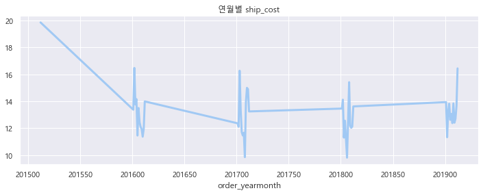

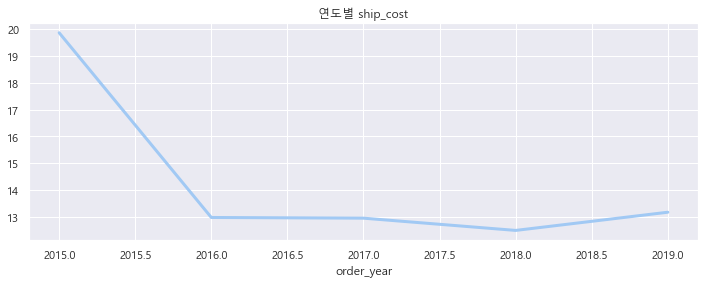

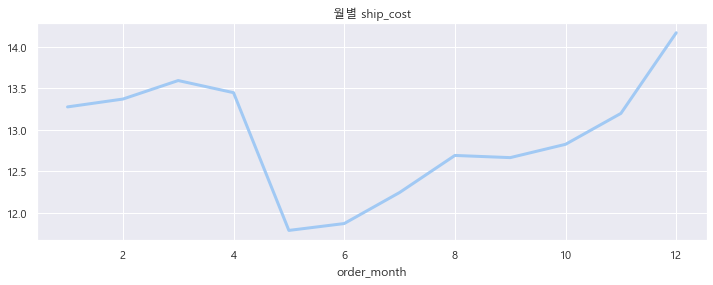

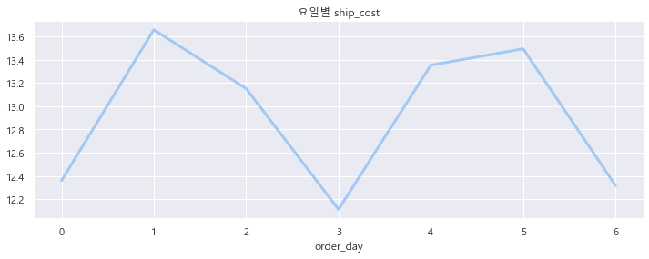

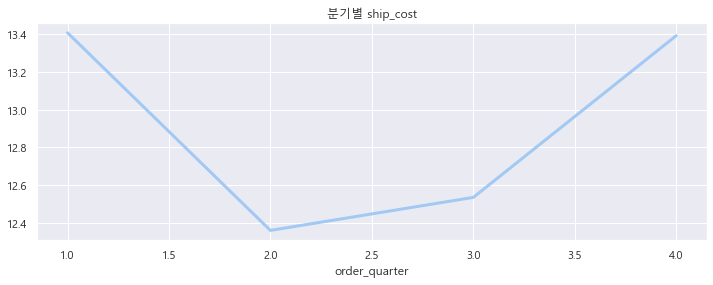

```python
plt.figure(figsize=(12,4));
EW_df.groupby("order_yearmonth").mean().ship_cost.plot(kind = "line", linewidth = 3);
plt.xticks(rotation=0);
plt.title('연월별 ship_cost');

plt.figure(figsize=(12,4));
EW_df.groupby("order_year").mean().ship_cost.plot(kind = "line", linewidth = 3);
plt.xticks(rotation=0);
plt.title('연도별 ship_cost');

plt.figure(figsize=(12,4));
EW_df.groupby("order_month").mean().ship_cost.plot(kind = "line", linewidth = 3);
plt.xticks(rotation=0);
plt.title('월별 ship_cost');

plt.figure(figsize=(12,4));
EW_df.groupby("order_day").mean().ship_cost.plot(kind = "line", linewidth = 3);
plt.xticks(rotation=0);
plt.title('요일별 ship_cost');

plt.figure(figsize=(12,4));
EW_df.groupby("order_quarter").mean().ship_cost.plot(kind = "line", linewidth = 3);
plt.xticks(rotation=0);

plt.title('분기별 ship_cost');
```

[월별]

- 5월에 배송비가 최저입니다.
- 1월 ~ 4월 , 11월 ~ 12월에 배송비가 비쌉니다.

[요일별]

- 월, 목, 일요일에 배송비가 싸고 나머지 요일에 비쌉니다.

** 매출이 좋으면 배송비도 비싸고 매출이 안좋으면 배송비도 저렴합니다.

## Ship mode 분석

```python
EW_df.groupby(['ship_mode','lead_time']).sum()
```

| ship_mode | lead_time | record_id | order_id | unit_price | order_quantity | sales | profit | ship_cost | discount_sub_mean | discount_mean | discount_zero | ... | order_yearmonth | order_year | order_month | order_day | order_quarter | ship_yearmonth | ship_year | ship_month | ship_day | ship_quarter |
| --- | --- | --- | --- | --- | --- | --- | --- | --- | --- | --- | --- | --- | --- | --- | --- | --- | --- | --- | --- | --- | --- | --- |
| Delivery Truck | 0 | 241450 | 2265381 | 19884.64 | 2364 | 4.752891e+05 | 27936.887254 | 3876.166 | 4.105246 | 4.096429 | 3.60 | ... | 16946295 | 169458 | 495 | 261 | 197 | 16946295 | 169458 | 495 | 261 | 197 |
|  | 1 | 655802 | 6159970 | 62476.74 | 5448 | 1.199469e+06 | 35848.331615 | 11096.959 | 11.367872 | 11.361786 | 8.83 | ... | 46603091 | 466015 | 1591 | 681 | 604 | 46603101 | 466015 | 1601 | 695 | 607 |
|  | 2 | 728982 | 7579970 | 80289.79 | 7159 | 1.562602e+06 | 70943.914877 | 11830.660 | 14.628220 | 14.627143 | 12.84 | ... | 56492961 | 564911 | 1861 | 904 | 712 | 56493249 | 564914 | 1849 | 862 | 711 |
|  | 3 | 124203 | 1176812 | 10129.57 | 976 | 2.173578e+05 | 12686.822134 | 1925.258 | 1.708940 | 1.707857 | 1.41 | ... | 8473174 | 84729 | 274 | 139 | 103 | 8473178 | 84729 | 278 | 118 | 105 |
|  | 4 | 80790 | 1016721 | 7890.19 | 991 | 2.392665e+05 | 23733.968554 | 1624.247 | 1.714932 | 1.718214 | 1.47 | ... | 6657205 | 66570 | 205 | 101 | 79 | 6657297 | 66571 | 197 | 107 | 76 |
|  | 5 | 101434 | 1175397 | 9746.01 | 1062 | 2.099095e+05 | 17531.906763 | 1628.571 | 2.074149 | 2.078571 | 1.88 | ... | 7869063 | 78688 | 263 | 125 | 102 | 7869070 | 78688 | 270 | 124 | 105 |
|  | 6 | 6985 | 129018 | 266.44 | 95 | 9.070017e+03 | 1032.358600 | 80.157 | 0.130000 | 0.130000 | 0.13 | ... | 605706 | 6057 | 6 | 6 | 3 | 605707 | 6057 | 7 | 10 | 3 |
|  | 7 | 103652 | 1112110 | 13028.36 | 930 | 2.521142e+05 | 13206.111734 | 1946.922 | 1.872631 | 1.867500 | 1.52 | ... | 7666321 | 76661 | 221 | 121 | 84 | 7666336 | 76661 | 236 | 121 | 89 |
|  | 9 | 14519 | 108285 | 1328.83 | 147 | 3.686004e+04 | 4683.154000 | 199.405 | 0.240000 | 0.240000 | 0.24 | ... | 1008730 | 10087 | 30 | 16 | 12 | 1008733 | 10087 | 33 | 19 | 13 |
|  | 17 | 1996 | 25436 | 130.98 | 45 | 5.785596e+03 | -423.768800 | 30.009 | 0.051227 | 0.049643 | 0.00 | ... | 201712 | 2017 | 12 | 3 | 4 | 201801 | 2018 | 1 | 6 | 1 |
| Express Air | 0 | 191803 | 2021989 | 4301.75 | 1788 | 8.809677e+04 | 14146.034300 | 574.448 | 3.914014 | 3.915714 | 3.32 | ... | 14526158 | 145257 | 458 | 219 | 177 | 14526158 | 145257 | 458 | 219 | 177 |
|  | 1 | 447048 | 5123547 | 7451.09 | 4425 | 1.912906e+05 | 27703.185500 | 1324.749 | 8.510083 | 8.502500 | 7.46 | ... | 34499986 | 344989 | 1086 | 569 | 418 | 34499989 | 344989 | 1089 | 509 | 418 |
|  | 2 | 588431 | 6023302 | 12021.88 | 5469 | 2.354533e+05 | 27385.336000 | 1696.533 | 10.675272 | 10.660000 | 9.27 | ... | 43777820 | 437764 | 1420 | 641 | 551 | 43778011 | 437766 | 1411 | 655 | 549 |
|  | 3 | 73479 | 688032 | 4331.70 | 660 | 2.624425e+04 | -7447.995200 | 168.996 | 1.245448 | 1.248571 | 1.05 | ... | 4841877 | 48417 | 177 | 69 | 67 | 4841881 | 48417 | 181 | 71 | 67 |
|  | 4 | 63600 | 717590 | 894.79 | 556 | 2.642396e+04 | 5798.290650 | 221.087 | 1.172500 | 1.168929 | 1.02 | ... | 4639854 | 46397 | 154 | 67 | 59 | 4639858 | 46397 | 158 | 75 | 59 |
|  | 5 | 62595 | 681069 | 1163.85 | 688 | 2.335548e+04 | 1917.290800 | 210.806 | 1.328429 | 1.328571 | 1.13 | ... | 4842847 | 48427 | 147 | 81 | 57 | 4842944 | 48428 | 144 | 75 | 57 |
|  | 6 | 10773 | 14763 | 144.27 | 62 | 3.167595e+03 | 262.806400 | 16.508 | 0.040000 | 0.040000 | 0.04 | ... | 403604 | 4036 | 4 | 6 | 2 | 403605 | 4036 | 5 | 11 | 2 |
|  | 7 | 74149 | 871446 | 2164.99 | 758 | 5.031791e+04 | 1164.823100 | 228.631 | 1.061958 | 1.058571 | 0.86 | ... | 5850824 | 58506 | 224 | 84 | 83 | 5850916 | 58507 | 216 | 84 | 82 |
|  | 9 | 18118 | 205058 | 453.26 | 162 | 8.429813e+03 | 1313.424200 | 65.884 | 0.170000 | 0.170000 | 0.17 | ... | 1210940 | 12109 | 40 | 18 | 15 | 1210942 | 12109 | 42 | 23 | 16 |
|  | 15 | 4049 | 47194 | 6.48 | 25 | 1.653656e+02 | -94.788800 | 7.499 | 0.090000 | 0.090000 | 0.09 | ... | 201712 | 2017 | 12 | 3 | 4 | 201801 | 2018 | 1 | 4 | 1 |
|  | 19 | 426 | 25807 | 125.99 | 43 | 4.687679e+03 | 1304.560200 | 8.089 | 0.060000 | 0.060000 | 0.06 | ... | 201712 | 2017 | 12 | 6 | 4 | 201801 | 2018 | 1 | 4 | 1 |
| Regular Air | 0 | 1231199 | 12259892 | 23477.21 | 11563 | 5.522261e+05 | 86503.967900 | 3598.490 | 23.711309 | 23.694286 | 20.12 | ... | 92802951 | 928000 | 2951 | 1524 | 1147 | 92802951 | 928000 | 2951 | 1524 | 1147 |
|  | 1 | 3620509 | 36426907 | 79955.75 | 33498 | 1.696041e+06 | 291105.584297 | 9882.734 | 63.224596 | 63.276786 | 54.49 | ... | 263487326 | 2634789 | 8426 | 4017 | 3242 | 263487635 | 2634792 | 8435 | 3986 | 3242 |
|  | 2 | 4499287 | 44239847 | 107668.78 | 42023 | 1.971038e+06 | 270886.367421 | 12514.660 | 81.569830 | 81.579286 | 70.36 | ... | 328868495 | 3288578 | 10695 | 4818 | 4107 | 328868849 | 3288581 | 10749 | 4921 | 4120 |
|  | 3 | 533744 | 5852618 | 15050.41 | 4845 | 2.358463e+05 | 33983.817100 | 1534.667 | 10.120003 | 10.136429 | 8.25 | ... | 40958115 | 409568 | 1315 | 606 | 506 | 40958217 | 409569 | 1317 | 634 | 509 |
|  | 4 | 571117 | 5444987 | 16875.02 | 5012 | 2.796114e+05 | 42358.125300 | 1443.491 | 9.179139 | 9.190000 | 7.80 | ... | 38130413 | 381292 | 1213 | 570 | 471 | 38130527 | 381293 | 1227 | 549 | 476 |
|  | 5 | 421481 | 4187181 | 5779.67 | 3421 | 1.211515e+05 | 13400.304742 | 1279.541 | 6.957698 | 6.951786 | 5.81 | ... | 30062138 | 300612 | 938 | 483 | 370 | 30062255 | 300613 | 955 | 423 | 374 |
|  | 6 | 4818 | 16447 | 55.98 | 2 | 1.071256e+02 | -54.868800 | 4.869 | 0.080000 | 0.080000 | 0.08 | ... | 201802 | 2018 | 2 | 1 | 1 | 201802 | 2018 | 2 | 0 | 1 |
|  | 7 | 464804 | 5123030 | 9343.25 | 5033 | 2.494269e+05 | 49165.778700 | 1541.943 | 9.157992 | 9.161429 | 7.97 | ... | 35707702 | 357065 | 1202 | 569 | 463 | 35708006 | 357068 | 1206 | 569 | 462 |
|  | 8 | 5311 | 104080 | 198.37 | 66 | 8.126239e+03 | 2461.095400 | 20.108 | 0.098633 | 0.099286 | 0.00 | ... | 403704 | 4037 | 4 | 6 | 2 | 403706 | 4037 | 6 | 8 | 2 |
|  | 9 | 143511 | 1333890 | 3385.61 | 1321 | 9.418185e+04 | 26738.683600 | 424.142 | 2.245264 | 2.247500 | 1.90 | ... | 9683822 | 96835 | 322 | 133 | 126 | 9684011 | 96837 | 311 | 145 | 124 |
|  | 11 | 8902 | 72630 | 156.96 | 35 | 2.404771e+03 | 720.162400 | 12.058 | 0.138019 | 0.139643 | 0.09 | ... | 403424 | 4034 | 24 | 6 | 8 | 403602 | 4036 | 2 | 0 | 2 |
|  | 17 | 4905 | 9505 | 65.99 | 17 | 9.590946e+02 | 124.993200 | 2.509 | 0.060000 | 0.060000 | 0.06 | ... | 201712 | 2017 | 12 | 1 | 4 | 201801 | 2018 | 1 | 4 | 1 |
|  | 24 | 3379 | 30341 | 7.99 | 4 | 3.112410e+01 | -46.902800 | 5.039 | 0.050000 | 0.050000 | 0.05 | ... | 201712 | 2017 | 12 | 6 | 4 | 201801 | 2018 | 1 | 2 | 1 |
|  | 27 | 1552 | 25807 | 11.97 | 17 | 2.130656e+02 | -31.738800 | 5.819 | 0.051610 | 0.049643 | 0.00 | ... | 201712 | 2017 | 12 | 6 | 4 | 201801 | 2018 | 1 | 5 | 1 |
|  | 28 | 398 | 25436 | 115.99 | 35 | 3.238149e+03 | 727.363200 | 4.239 | 0.047800 | 0.049643 | 0.00 | ... | 201712 | 2017 | 12 | 3 | 4 | 201801 | 2018 | 1 | 3 | 1 |
|  | 31 | 3880 | 25807 | 195.99 | 7 | 1.126494e+03 | -557.951800 | 4.209 | 0.080000 | 0.080000 | 0.08 | ... | 201712 | 2017 | 12 | 6 | 4 | 201801 | 2018 | 1 | 2 | 1 |
|  | 84 | 4176 | 2222 | 11.09 | 40 | 4.308856e+02 | 39.001200 | 5.259 | 0.050000 | 0.050000 | 0.05 | ... | 201712 | 2017 | 12 | 2 | 4 | 201803 | 2018 | 3 | 2 | 1 |
|  | 92 | 4993 | 472 | 2.21 | 21 | 4.694560e+01 | 3.881200 | 1.009 | 0.020000 | 0.020000 | 0.02 | ... | 201712 | 2017 | 12 | 3 | 4 | 201803 | 2018 | 3 | 4 | 1 |

39 rows × 23 columns

```python
EW_df.query("lead_time > 5").groupby(['ship_mode','product_category', 'product_sub_category', 'order_quantity', 'lead_time','product_container']).profit.sum().sort_values(ascending=True).iloc[:10]
```

```
ship_mode       product_category  product_sub_category    order_quantity  lead_time  product_container
Delivery Truck  Technology        Office Machines         3               7          Jumbo Drum          -3974.8101
                Furniture         Tables                  50              7          Jumbo Box           -1820.8388
                                                          24              7          Jumbo Box           -1565.8888
                                                          45              7          Jumbo Box           -1430.4498
Express Air     Technology        Copiers and Fax         46              7          Large Box           -1312.8388
Delivery Truck  Furniture         Tables                  26              7          Jumbo Box           -1096.7748
                                                          21              7          Jumbo Box           -1043.2181
Regular Air     Office Supplies   Appliances              33              7          Large Box            -991.0688
Delivery Truck  Furniture         Tables                  40              7          Jumbo Box            -973.2988
Regular Air     Office Supplies   Storage & Organization  29              7          Large Box            -888.0688
Name: profit, dtype: float64
```

```python
EW_df.query(" lead_time > 5 & product_container == 'Large Box'").groupby(['ship_mode']).order_id.count().sort_values()
```

```
ship_mode
Express Air     3
Regular Air    12
Name: order_id, dtype: int64
```

```python
EW_df.query(" lead_time > 5 & product_container == 'Jumbo Drum'").groupby(['ship_mode']).order_id.count().sort_values()
```

```
ship_mode
Delivery Truck    22
Name: order_id, dtype: int64
```

- 출고 기간이 5일 이상 걸리는 수가 적지 않습니다. 출고까지의 시간이 걸리는 이유에 대해 파악하는 것이 필요합니다.
- 제품 주문한 날부터 출고되는 날까지 시간이 길 수록 손해가 크다고 생각합니다. 특히 Product Container의 종류가 대형일수록 배송시간이 더 걸릴 것이고 따라서 출고일을 앞당기는 것이 좋다고 생각합니다.

## 상품 단가 분석

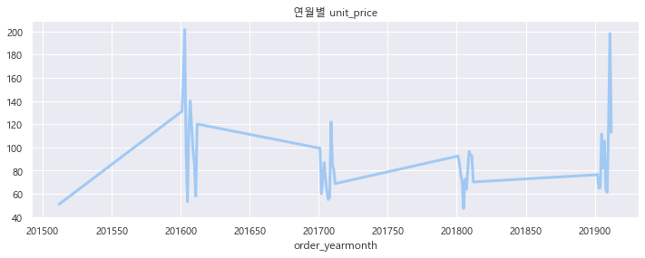

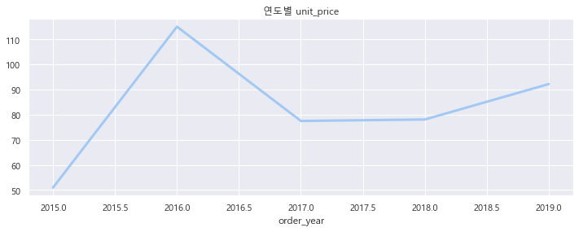

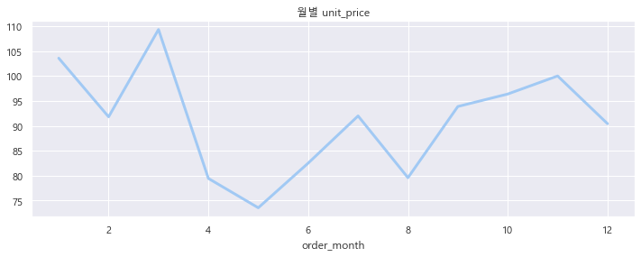

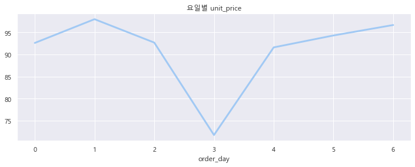

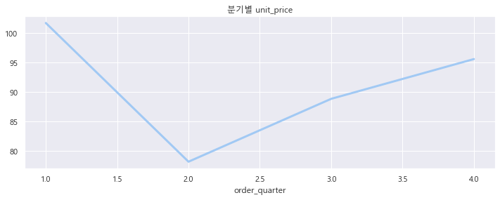

```python
plt.figure(figsize=(12,4));
EW_df.groupby("order_yearmonth").mean().unit_price.plot(kind = "line", linewidth = 3);
plt.xticks(rotation=0);
plt.title('연월별 unit_price');

plt.figure(figsize=(12,4));
EW_df.groupby("order_year").mean().unit_price.plot(kind = "line", linewidth = 3);
plt.xticks(rotation=0);
plt.title('연도별 unit_price');

plt.figure(figsize=(12,4));
EW_df.groupby("order_month").mean().unit_price.plot(kind = "line", linewidth = 3);
plt.xticks(rotation=0);
plt.title('월별 unit_price');

plt.figure(figsize=(12,4));
EW_df.groupby("order_day").mean().unit_price.plot(kind = "line", linewidth = 3);
plt.xticks(rotation=0);
plt.title('요일별 unit_price');

plt.figure(figsize=(12,4));
EW_df.groupby("order_quarter").mean().unit_price.plot(kind = "line", linewidth = 3);
plt.xticks(rotation=0);

plt.title('분기별 unit_price');
```

[연도별]

- 2015년에 제일 단가가 낮습니다.
- 2016년에 가장 단가가 높습니다.

[월별]

- 4, 5, 8월에 단가가 낮음 상품들이 많습니다.
- 1, 3, 11월에 단가가 높은 상품이 많이 판매됩니다.

[요일별]

- 목요일에 압도적으로 주문 단가가 낮습니다.

[분기별]

- 1분기에 단가가 가장 높고 2분기에 최하를 기록하고 점점 증가합니다.

4, 5, 8월에 단가가 낮은 상품들이 많고 1, 3, 11월에 단가가 높은 상품들이 많습니다.

상품단가 낮은 달

4월

```python
EW_df.sort_values(by = "order_quantity", ascending=False).query("order_month == 4").loc[:,("product_name","order_quantity","unit_price")].head(20)
```

|  | product_name | order_quantity | unit_price |
| --- | --- | --- | --- |
| 4939 | Accessory39 | 50 | 20.99 |
| 6205 | Belkin 8 Outlet SurgeMaster II Gold Surge Prot... | 50 | 59.98 |
| 840 | Staples Bulk Pack Metal Binder Clips | 50 | 6.08 |
| 1766 | Imation Primaris 3.5" 2HD Unformatted Diskette... | 50 | 4.77 |
| 1469 | Accessory23 | 50 | 35.99 |
| 6911 | Martin-Yale Premier Letter Opener | 50 | 12.88 |
| 615 | Adams "While You Were Out" Message Pads | 50 | 3.14 |
| 2703 | O'Sullivan 5-Shelf Heavy-Duty Bookcases | 50 | 81.94 |
| 1616 | O'Sullivan 3-Shelf Heavy-Duty Bookcases | 50 | 58.14 |
| 2819 | Bionaire Personal Warm Mist Humidifier/Vaporizer | 50 | 46.89 |
| 4769 | Newell 325 | 50 | 4.13 |
| 4096 | Fellowes Personal Hanging Folder Files, Navy | 49 | 13.43 |
| 6430 | SANFORD Major Accent™ Highlighters | 49 | 7.08 |
| 2818 | Bush Advantage Collection Round Conference Table | 49 | 212.60 |
| 4017 | Tripp Lite Isotel 8 Ultra 8 Outlet Metal Surge | 49 | 70.97 |
| 4701 | Xerox 220 | 49 | 6.48 |
| 5881 | Acco Recycled 2" Capacity Laser Printer Hangin... | 49 | 14.45 |
| 1272 | Hon 94000 Series Round Tables | 49 | 296.18 |
| 173 | Master Caster Door Stop, Large Neon Orange | 49 | 7.28 |
| 6366 | Adesso Programmable 142-Key Keyboard | 49 | 152.48 |

```python
EW_df.sort_values(by = "order_quantity", ascending=False).query("order_month == 4").loc[:,("product_sub_category","order_quantity","unit_price")].head(20)
```

|  | product_sub_category | order_quantity | unit_price |
| --- | --- | --- | --- |
| 4939 | Telephones and Communication | 50 | 20.99 |
| 6205 | Appliances | 50 | 59.98 |
| 840 | Rubber Bands | 50 | 6.08 |
| 1766 | Computer Peripherals | 50 | 4.77 |
| 1469 | Telephones and Communication | 50 | 35.99 |
| 6911 | Scissors, Rulers and Trimmers | 50 | 12.88 |
| 615 | Paper | 50 | 3.14 |
| 2703 | Bookcases | 50 | 81.94 |
| 1616 | Bookcases | 50 | 58.14 |
| 2819 | Appliances | 50 | 46.89 |
| 4769 | Pens & Art Supplies | 50 | 4.13 |
| 4096 | Storage & Organization | 49 | 13.43 |
| 6430 | Pens & Art Supplies | 49 | 7.08 |
| 2818 | Tables | 49 | 212.60 |
| 4017 | Appliances | 49 | 70.97 |
| 4701 | Paper | 49 | 6.48 |
| 5881 | Binders and Binder Accessories | 49 | 14.45 |
| 1272 | Tables | 49 | 296.18 |
| 173 | Office Furnishings | 49 | 7.28 |
| 6366 | Computer Peripherals | 49 | 152.48 |

5월

```python
EW_df.sort_values(by = "order_quantity", ascending=False).query("order_month == 5").loc[:,("product_name","order_quantity","unit_price")].head(20)
```

|  | product_name | order_quantity | unit_price |
| --- | --- | --- | --- |
| 5354 | Office Star - Contemporary Task Swivel chair w... | 50 | 130.98 |
| 3119 | Xerox 231 | 50 | 6.48 |
| 261 | Avery Hanging File Binders | 50 | 5.98 |
| 1072 | Staples #10 Laser & Inkjet Envelopes, 4 1/8" x... | 50 | 9.78 |
| 2999 | Southworth 25% Cotton Premium Laser Paper and ... | 50 | 19.98 |
| 4353 | Accessory20 | 50 | 85.99 |
| 5742 | Vinyl Sectional Post Binders | 50 | 37.70 |
| 3116 | Angle-D Binders with Locking Rings, Label Holders | 50 | 7.30 |
| 1498 | Nu-Dell Executive Frame | 50 | 12.64 |
| 1228 | Assorted Color Push Pins | 50 | 1.81 |
| 6778 | 9-3/4 Diameter Round Wall Clock | 49 | 13.79 |
| 1999 | Document Clip Frames | 49 | 8.34 |
| 825 | Staples Colored Interoffice Envelopes | 49 | 30.98 |
| 373 | Accessory34 | 49 | 85.99 |
| 473 | 1726 Digital Answering Machine | 49 | 20.99 |
| 1458 | Brother DCP1000 Digital 3 in 1 Multifunction M... | 49 | 299.99 |
| 1274 | Avery 493 | 49 | 4.91 |
| 4613 | Avery 474 | 49 | 2.88 |
| 4137 | Office Star - Mid Back Dual function Ergonomic... | 49 | 160.98 |
| 444 | SouthWestern Bell FA970 Digital Answering Mach... | 49 | 28.99 |

5월에 평균 주문 수량이 가장 많은데 상품단가가 낮은 상품들이 주를 이루고 있습니다.

```python
EW_df.sort_values(by = "order_quantity", ascending=False).query("order_month == 5").loc[:,("product_sub_category","order_quantity","unit_price")].head(20)
```

|  | product_sub_category | order_quantity | unit_price |
| --- | --- | --- | --- |
| 5354 | Chairs & Chairmats | 50 | 130.98 |
| 3119 | Paper | 50 | 6.48 |
| 261 | Binders and Binder Accessories | 50 | 5.98 |
| 1072 | Envelopes | 50 | 9.78 |
| 2999 | Paper | 50 | 19.98 |
| 4353 | Telephones and Communication | 50 | 85.99 |
| 5742 | Binders and Binder Accessories | 50 | 37.70 |
| 3116 | Binders and Binder Accessories | 50 | 7.30 |
| 1498 | Office Furnishings | 50 | 12.64 |
| 1228 | Rubber Bands | 50 | 1.81 |
| 6778 | Office Furnishings | 49 | 13.79 |
| 1999 | Office Furnishings | 49 | 8.34 |
| 825 | Envelopes | 49 | 30.98 |
| 373 | Telephones and Communication | 49 | 85.99 |
| 473 | Telephones and Communication | 49 | 20.99 |
| 1458 | Copiers and Fax | 49 | 299.99 |
| 1274 | Labels | 49 | 4.91 |
| 4613 | Labels | 49 | 2.88 |
| 4137 | Chairs & Chairmats | 49 | 160.98 |
| 444 | Telephones and Communication | 49 | 28.99 |

8월

```python
EW_df.sort_values(by = "order_quantity", ascending=False).query("order_month == 8").loc[:,("product_name","order_quantity","unit_price")].head(20)
```

|  | product_name | order_quantity | unit_price |
| --- | --- | --- | --- |
| 2270 | White Dual Perf Computer Printout Paper, 2700 ... | 50 | 40.99 |
| 2295 | Global Leather & Oak Executive Chair, Burgundy | 50 | 150.89 |
| 1644 | Avery Durable Slant Ring Binders With Label Ho... | 50 | 4.18 |
| 1413 | Accessory35 | 50 | 35.99 |
| 5546 | GBC Pre-Punched Binding Paper, Plastic, White,... | 50 | 15.99 |
| 5133 | DAX Cubicle Frames - 8x10 | 50 | 5.77 |
| 6200 | Xerox 1893 | 50 | 40.99 |
| 1325 | Avery 510 | 50 | 3.75 |
| 1857 | Avery Binder Labels | 50 | 3.89 |
| 5125 | Newell 323 | 49 | 1.68 |
| 3629 | Hon Metal Bookcases, Black | 49 | 70.98 |
| 6112 | Seth Thomas 8 1/2" Cubicle Clock | 49 | 20.28 |
| 3653 | Staples Paper Clips | 49 | 2.47 |
| 7055 | Vinyl Sectional Post Binders | 49 | 37.70 |
| 4853 | Acme Office Executive Series Stainless Steel T... | 49 | 8.57 |
| 6288 | Accessory13 | 48 | 35.99 |
| 5416 | Tenex Carpeted, Granite-Look or Clear Contempo... | 48 | 70.71 |
| 4417 | i500plus | 48 | 65.99 |
| 203 | Coloredge Poster Frame | 48 | 14.20 |
| 765 | Dixon Ticonderoga Core-Lock Colored Pencils | 48 | 9.11 |

```python
EW_df.sort_values(by = "order_quantity", ascending=False).query("order_month == 8").loc[:,("product_sub_category","order_quantity","unit_price")].head(20)
```

|  | product_sub_category | order_quantity | unit_price |
| --- | --- | --- | --- |
| 2270 | Paper | 50 | 40.99 |
| 2295 | Chairs & Chairmats | 50 | 150.89 |
| 1644 | Binders and Binder Accessories | 50 | 4.18 |
| 1413 | Telephones and Communication | 50 | 35.99 |
| 5546 | Binders and Binder Accessories | 50 | 15.99 |
| 5133 | Office Furnishings | 50 | 5.77 |
| 6200 | Paper | 50 | 40.99 |
| 1325 | Labels | 50 | 3.75 |
| 1857 | Binders and Binder Accessories | 50 | 3.89 |
| 5125 | Pens & Art Supplies | 49 | 1.68 |
| 3629 | Bookcases | 49 | 70.98 |
| 6112 | Office Furnishings | 49 | 20.28 |
| 3653 | Rubber Bands | 49 | 2.47 |
| 7055 | Binders and Binder Accessories | 49 | 37.70 |
| 4853 | Scissors, Rulers and Trimmers | 49 | 8.57 |
| 6288 | Telephones and Communication | 48 | 35.99 |
| 5416 | Office Furnishings | 48 | 70.71 |
| 4417 | Telephones and Communication | 48 | 65.99 |
| 203 | Office Furnishings | 48 | 14.20 |
| 765 | Pens & Art Supplies | 48 | 9.11 |

상품단가 높은 달

1월

```python
EW_df.sort_values(by = "order_quantity", ascending=False).query("order_month == 1").loc[:,("product_name","order_quantity","unit_price")].head(20)
```

|  | product_name | order_quantity | unit_price |
| --- | --- | --- | --- |
| 6431 | Xerox 1903 | 50 | 5.98 |
| 1878 | Accessory21 | 50 | 20.99 |
| 6955 | Avery Arch Ring Binders | 50 | 58.10 |
| 1075 | Staples 4 Outlet Surge Protector | 50 | 8.67 |
| 7000 | Airmail Envelopes | 50 | 83.93 |
| 3074 | Ibico EB-19 Dual Function Manual Binding System | 50 | 172.99 |
| 4139 | Xerox 210 | 50 | 6.48 |
| 3581 | Acme 8" Straight Scissors | 50 | 12.98 |
| 2312 | GBC Poly Designer Binding Covers | 50 | 16.74 |
| 6291 | OIC Thumb-Tacks | 50 | 1.14 |
| 3628 | Canon Image Class D660 Copier | 49 | 599.99 |
| 4919 | Panasonic KX-P3200 Dot Matrix Printer | 49 | 297.64 |
| 5513 | Eldon ClusterMat Chair Mat with Cordless Antis... | 49 | 90.98 |
| 2113 | Polycom ViaVideo™ Desktop Video Communications... | 49 | 574.74 |
| 2804 | Park Ridge™ Embossed Executive Business Envelopes | 49 | 15.57 |
| 6251 | Catalog Binders with Expanding Posts | 49 | 67.28 |
| 3221 | Fellowes EZ Multi-Media Keyboard | 48 | 34.98 |
| 2093 | Kensington 7 Outlet MasterPiece Power Center w... | 48 | 207.48 |
| 5329 | Global Troy™ Executive Leather Low-Back Tilter | 48 | 500.98 |
| 4893 | Acco PRESSTEX Data Binder with Storage Hooks, ... | 48 | 5.38 |

```python
EW_df.sort_values(by = "order_quantity", ascending=False).query("order_month == 1").loc[:,("product_sub_category","order_quantity","unit_price")].head(20)
```

|  | product_sub_category | order_quantity | unit_price |
| --- | --- | --- | --- |
| 6431 | Paper | 50 | 5.98 |
| 1878 | Telephones and Communication | 50 | 20.99 |
| 6955 | Binders and Binder Accessories | 50 | 58.10 |
| 1075 | Appliances | 50 | 8.67 |
| 7000 | Envelopes | 50 | 83.93 |
| 3074 | Binders and Binder Accessories | 50 | 172.99 |
| 4139 | Paper | 50 | 6.48 |
| 3581 | Scissors, Rulers and Trimmers | 50 | 12.98 |
| 2312 | Binders and Binder Accessories | 50 | 16.74 |
| 6291 | Rubber Bands | 50 | 1.14 |
| 3628 | Copiers and Fax | 49 | 599.99 |
| 4919 | Office Machines | 49 | 297.64 |
| 5513 | Office Furnishings | 49 | 90.98 |
| 2113 | Office Machines | 49 | 574.74 |
| 2804 | Envelopes | 49 | 15.57 |
| 6251 | Binders and Binder Accessories | 49 | 67.28 |
| 3221 | Computer Peripherals | 48 | 34.98 |
| 2093 | Appliances | 48 | 207.48 |
| 5329 | Chairs & Chairmats | 48 | 500.98 |
| 4893 | Binders and Binder Accessories | 48 | 5.38 |

3월

```python
EW_df.sort_values(by = "order_quantity", ascending=False).query("order_month == 3").loc[:,("product_name","order_quantity","unit_price")].head(20)
```

|  | product_name | order_quantity | unit_price |
| --- | --- | --- | --- |
| 5334 | Memorex 4.7GB DVD+RW, 3/Pack | 50 | 28.48 |
| 1471 | Canon MP25DIII Desktop Whisper-Quiet Printing ... | 50 | 51.98 |
| 5205 | Xerox 1951 | 50 | 30.98 |
| 2639 | Avery Hanging File Binders | 50 | 5.98 |
| 2646 | I888 World Phone | 50 | 155.99 |
| 99 | GBC Standard Therm-A-Bind Covers | 50 | 24.92 |
| 5645 | Hewlett Packard LaserJet 3310 Copier | 50 | 599.99 |
| 1753 | PC Concepts 116 Key Quantum 3000 Keyboard | 50 | 32.98 |
| 7101 | BPI Conference Tables | 50 | 146.05 |
| 1722 | Hon Deluxe Fabric Upholstered Stacking Chairs,... | 50 | 243.98 |
| 859 | Iceberg OfficeWorks 42" Round Tables | 50 | 150.98 |
| 3404 | Recycled Steel Personal File for Standard File... | 50 | 55.29 |
| 6648 | Deflect-o EconoMat Nonstudded, No Bevel Mat | 49 | 51.65 |
| 7123 | Dana Halogen Swing-Arm Architect Lamp | 49 | 40.97 |
| 856 | Ibico Hi-Tech Manual Binding System | 49 | 304.99 |
| 5408 | Adams Telephone Message Book W/Dividers/Space ... | 49 | 5.88 |
| 1187 | Xerox 1962 | 48 | 4.28 |
| 3699 | SANFORD Liquid Accent™ Tank-Style Highlighters | 48 | 2.84 |
| 1185 | Executive Impressions 8-1/2" Career Panel/Part... | 48 | 10.40 |
| 5777 | Newell 314 | 48 | 5.58 |

```python
EW_df.sort_values(by = "order_quantity", ascending=False).query("order_month == 3").loc[:,("product_sub_category","order_quantity","unit_price")].head(20)
```

|  | product_sub_category | order_quantity | unit_price |
| --- | --- | --- | --- |
| 5334 | Computer Peripherals | 50 | 28.48 |
| 1471 | Office Machines | 50 | 51.98 |
| 5205 | Paper | 50 | 30.98 |
| 2639 | Binders and Binder Accessories | 50 | 5.98 |
| 2646 | Telephones and Communication | 50 | 155.99 |
| 99 | Binders and Binder Accessories | 50 | 24.92 |
| 5645 | Copiers and Fax | 50 | 599.99 |
| 1753 | Computer Peripherals | 50 | 32.98 |
| 7101 | Tables | 50 | 146.05 |
| 1722 | Chairs & Chairmats | 50 | 243.98 |
| 859 | Tables | 50 | 150.98 |
| 3404 | Storage & Organization | 50 | 55.29 |
| 6648 | Office Furnishings | 49 | 51.65 |
| 7123 | Office Furnishings | 49 | 40.97 |
| 856 | Binders and Binder Accessories | 49 | 304.99 |
| 5408 | Paper | 49 | 5.88 |
| 1187 | Paper | 48 | 4.28 |
| 3699 | Pens & Art Supplies | 48 | 2.84 |
| 1185 | Office Furnishings | 48 | 10.40 |
| 5777 | Pens & Art Supplies | 48 | 5.58 |

11월

```python
EW_df.sort_values(by = "order_quantity", ascending=False).query("order_month == 11").loc[:,("product_name","order_quantity","unit_price")].head(20)
```

|  | product_name | order_quantity | unit_price |
| --- | --- | --- | --- |
| 4807 | Avery Flip-Chart Easel Binder, Black | 50 | 22.38 |
| 6376 | Verbatim DVD-RAM, 9.4GB, Rewritable, Type 1, D... | 50 | 45.19 |
| 5145 | Ultra Door Push Plate | 50 | 4.91 |
| 1882 | TimeportP7382 | 50 | 205.99 |
| 2919 | Companion Letter/Legal File, Black | 50 | 37.76 |
| 5907 | US Robotics 56K V.92 Internal PCI Faxmodem | 50 | 49.99 |
| 6948 | O'Sullivan 3-Shelf Heavy-Duty Bookcases | 50 | 58.14 |
| 1494 | Fellowes PB300 Plastic Comb Binding Machine | 49 | 387.99 |
| 2781 | Newell 329 | 49 | 3.28 |
| 1225 | Economy Rollaway Files | 49 | 165.20 |
| 2345 | Maxell Pro 80 Minute CD-R, 10/Pack | 49 | 17.48 |
| 2558 | Xerox 1916 | 49 | 48.94 |
| 1199 | Belkin F5C206VTEL 6 Outlet Surge | 49 | 22.98 |
| 2074 | Accessory31 | 48 | 35.99 |
| 6658 | Nu-Dell Executive Frame | 48 | 12.64 |
| 4750 | Project Tote Personal File | 48 | 14.03 |
| 1648 | Prang Drawing Pencil Set | 48 | 2.78 |
| 4788 | Hammermill CopyPlus Copy Paper (20Lb. and 84 B... | 48 | 4.98 |
| 3205 | M70 | 48 | 125.99 |
| 6267 | Rush Hierlooms Collection Rich Wood Bookcases | 48 | 160.98 |

```python
EW_df.sort_values(by = "order_quantity", ascending=False).query("order_month == 11").loc[:,("product_sub_category","order_quantity","unit_price")].head(20)
```

|  | product_sub_category | order_quantity | unit_price |
| --- | --- | --- | --- |
| 4807 | Binders and Binder Accessories | 50 | 22.38 |
| 6376 | Computer Peripherals | 50 | 45.19 |
| 5145 | Office Furnishings | 50 | 4.91 |
| 1882 | Telephones and Communication | 50 | 205.99 |
| 2919 | Storage & Organization | 50 | 37.76 |
| 5907 | Computer Peripherals | 50 | 49.99 |
| 6948 | Bookcases | 50 | 58.14 |
| 1494 | Binders and Binder Accessories | 49 | 387.99 |
| 2781 | Pens & Art Supplies | 49 | 3.28 |
| 1225 | Storage & Organization | 49 | 165.20 |
| 2345 | Computer Peripherals | 49 | 17.48 |
| 2558 | Paper | 49 | 48.94 |
| 1199 | Appliances | 49 | 22.98 |
| 2074 | Telephones and Communication | 48 | 35.99 |
| 6658 | Office Furnishings | 48 | 12.64 |
| 4750 | Storage & Organization | 48 | 14.03 |
| 1648 | Pens & Art Supplies | 48 | 2.78 |
| 4788 | Paper | 48 | 4.98 |
| 3205 | Telephones and Communication | 48 | 125.99 |
| 6267 | Bookcases | 48 | 160.98 |

Office Machines / Coppier / Tabels 에 대한 마케팅 전략 필요합니다.

## 주문 수량 분석

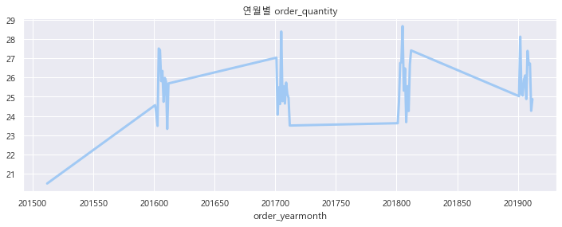

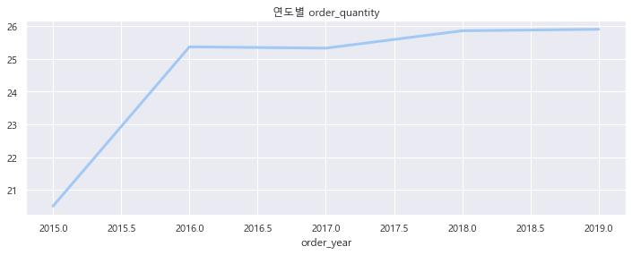

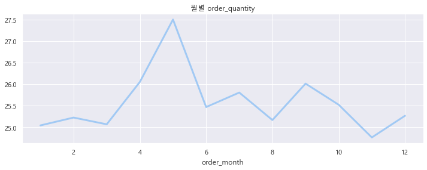

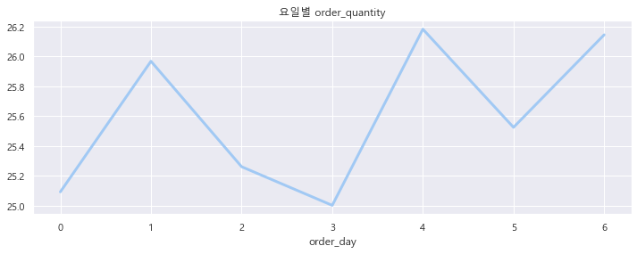

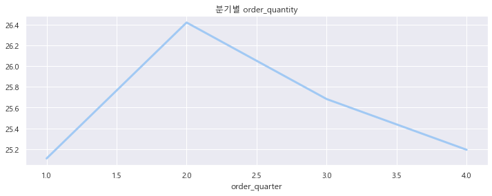

```python
plt.figure(figsize=(12,4));
EW_df.groupby("order_yearmonth").mean().order_quantity.plot(kind = "line", linewidth = 3);
plt.xticks(rotation=0);
plt.title('연월별 order_quantity');

plt.figure(figsize=(12,4));
EW_df.groupby("order_year").mean().order_quantity.plot(kind = "line", linewidth = 3);
plt.xticks(rotation=0);
plt.title('연도별 order_quantity');

plt.figure(figsize=(12,4));
EW_df.groupby("order_month").mean().order_quantity.plot(kind = "line", linewidth = 3);
plt.xticks(rotation=0);
plt.title('월별 order_quantity');

plt.figure(figsize=(12,4));
EW_df.groupby("order_day").mean().order_quantity.plot(kind = "line", linewidth = 3);
plt.xticks(rotation=0);
plt.title('요일별 order_quantity');

plt.figure(figsize=(12,4));
EW_df.groupby("order_quarter").mean().order_quantity.plot(kind = "line", linewidth = 3);
plt.xticks(rotation=0);

plt.title('분기별 order_quantity');
```

[연도별]

- 주문 수량이 2015년에서 2016년에 급증한 뒤로 유지합니다.

[월별]

- 5월에 주문 수량이 가장 많습니다.
- 주문 수량이 낮은 1, 2, 3, 8, 11월에 어떤 상품이 주로 판매되는지 살펴보는 것이 좋겠습니다.

[요일별]

- 월요일, 수요일, 목요일에 주문 수량이 적습니다.
- 화요일, 금요일, 일요일에 주문 수량이 많습니다.

[분기별]

- 상품 단가와 반대로 1분기에 가장 주문 수량이 적고 2분기에 최고점에 도달하고 점점 감소합니다.

## 매출 분석

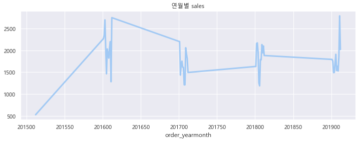

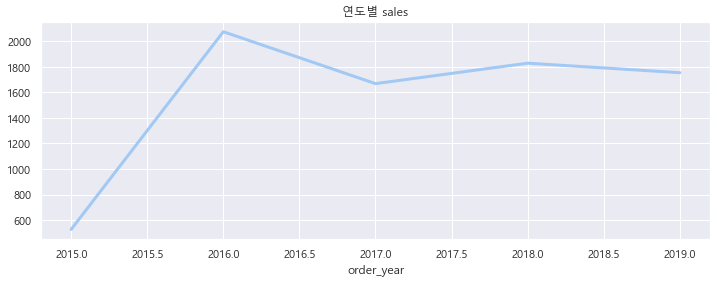

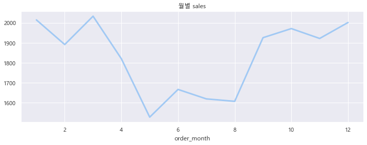

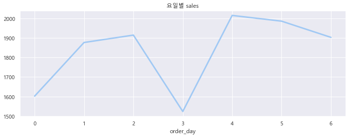

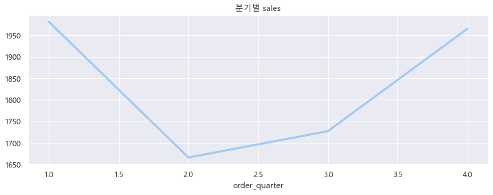

```python
plt.figure(figsize=(12,4));
EW_df.groupby("order_yearmonth").mean().sales.plot(kind = "line", linewidth = 3);
plt.xticks(rotation=0);
plt.title('연월별 sales');

plt.figure(figsize=(12,4));
EW_df.groupby("order_year").mean().sales.plot(kind = "line", linewidth = 3);
plt.xticks(rotation=0);
plt.title('연도별 sales');

plt.figure(figsize=(12,4));
EW_df.groupby("order_month").mean().sales.plot(kind = "line", linewidth = 3);
plt.xticks(rotation=0);
plt.title('월별 sales');

plt.figure(figsize=(12,4));
EW_df.groupby("order_day").mean().sales.plot(kind = "line", linewidth = 3);
plt.xticks(rotation=0);
plt.title('요일별 sales');

plt.figure(figsize=(12,4));
EW_df.groupby("order_quarter").mean().sales.plot(kind = "line", linewidth = 3);
plt.xticks(rotation=0);

plt.title('분기별 sales');
```

[연도별]

- 상품 주문 수량과 비슷한 양상을 보입니다.

[월별]

- 5월 ~ 8월에 매출이 적습니다.

[요일별]

- 월요일과 목요일에 매출이 적습니다.

[분기별]

- 분기별로는 오히려 주문수량이 아닌 상품 단가와 비슷한 양상을 보입니다.

## 이윤 분석

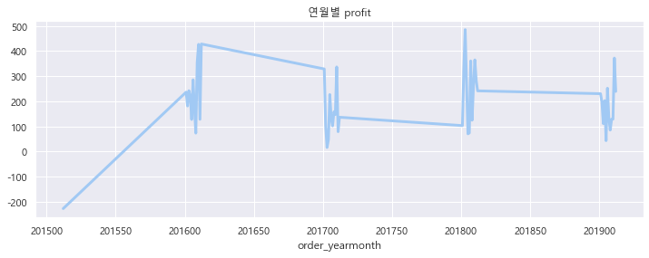

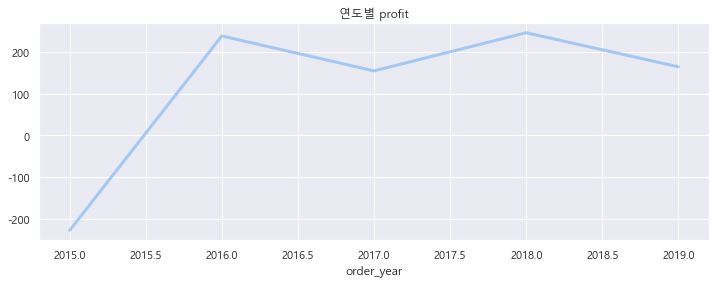

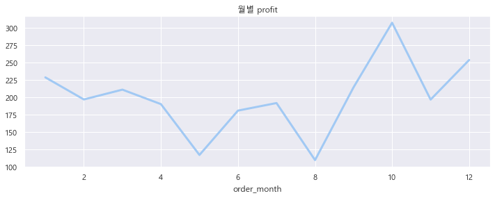

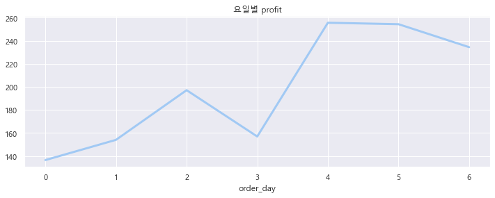

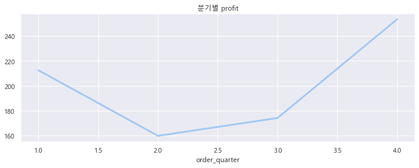

```python
plt.figure(figsize=(12,4));
EW_df.groupby("order_yearmonth").mean().profit.plot(kind = "line", linewidth = 3);
plt.xticks(rotation=0);
plt.title('연월별 profit');

plt.figure(figsize=(12,4));
EW_df.groupby("order_year").mean().profit.plot(kind = "line", linewidth = 3);
plt.xticks(rotation=0);
plt.title('연도별 profit');

plt.figure(figsize=(12,4));
EW_df.groupby("order_month").mean().profit.plot(kind = "line", linewidth = 3);
plt.xticks(rotation=0);
plt.title('월별 profit');

plt.figure(figsize=(12,4));
EW_df.groupby("order_day").mean().profit.plot(kind = "line", linewidth = 3);
plt.xticks(rotation=0);
plt.title('요일별 profit');

plt.figure(figsize=(12,4));
EW_df.groupby("order_quarter").mean().profit.plot(kind = "line", linewidth = 3);
plt.xticks(rotation=0);

plt.title('분기별 profit');
```

[연도별]

[월별]

- 3월에 매출은 높지만 이익은 낮습니다.
- 7월에 매출은 낮지만 이익은 높습니다.
- 9월에 매출은 높지만 이익은 낮습니다.

[요일별]

- 화요일에 매출은 높지만 이익은 낮습니다.

[분기별]

- 매출 : 1분기 > 4분기
- 이익 : 1분기 < 4분기

## 할인율 분석

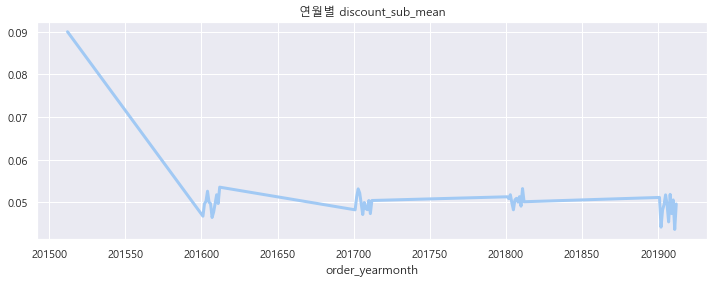

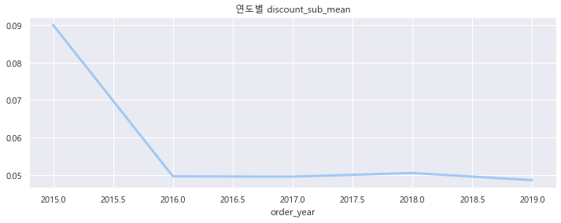

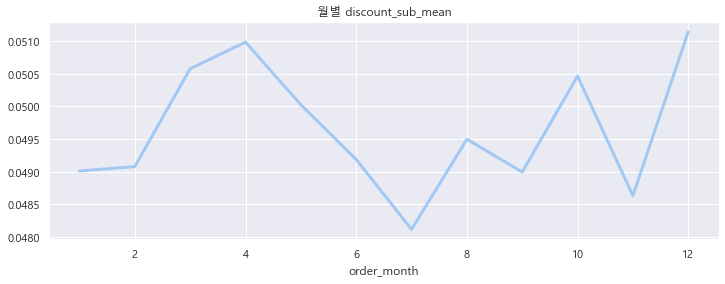

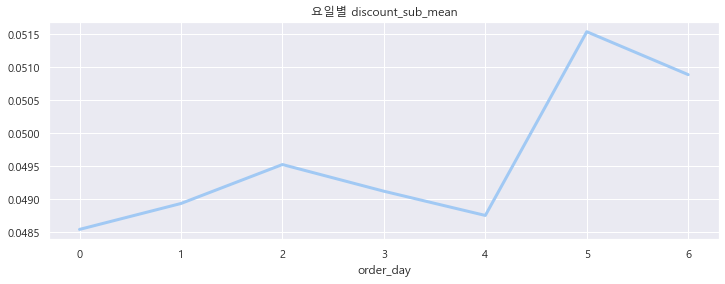

[figure not shown]

```python
plt.figure(figsize=(12,4));
EW_df.groupby("order_yearmonth").mean().discount_sub_mean.plot(kind = "line", linewidth = 3);
plt.xticks(rotation=0);
plt.title('연월별 discount_sub_mean');

plt.figure(figsize=(12,4));
EW_df.groupby("order_year").mean().discount_sub_mean.plot(kind = "line", linewidth = 3);
plt.xticks(rotation=0);
plt.title('연도별 discount_sub_mean');

plt.figure(figsize=(12,4));
EW_df.groupby("order_month").mean().discount_sub_mean.plot(kind = "line", linewidth = 3);
plt.xticks(rotation=0);
plt.title('월별 discount_sub_mean');

plt.figure(figsize=(12,4));
EW_df.groupby("order_day").mean().discount_sub_mean.plot(kind = "line", linewidth = 3);
plt.xticks(rotation=0);
plt.title('요일별 discount_sub_mean');

plt.figure(figsize=(12,4));
EW_df.groupby("order_quarter").mean().discount_sub_mean.plot(kind = "line", linewidth = 3);
plt.xticks(rotation=0);
plt.legend(['unit_price', 'order_quantity',"sales","profit","ship_cost","discount_sub_mean","discount_mean","discount_zero","product_base_margin_sub_mean","product_base_margin_mean","new_sales"])
plt.title('분기별 discount_sub_mean');
```

[년도별]

[월별]

- 3월, 4월, 12월에 세일을 진행했지만 할인율이 너무 낮습니다.
- 6월, 7월의 세일이 좋아하지 않아서 추가 판매촉진 전략이 필요합니다.

[요일별]

[분기별]

- 3분기에 할인율 가장 낮습니다.

## 마진율 분석

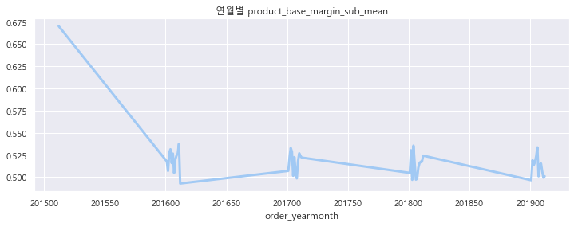

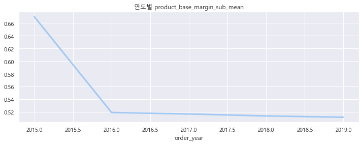

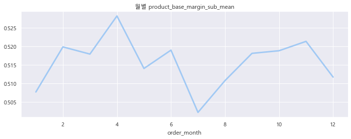

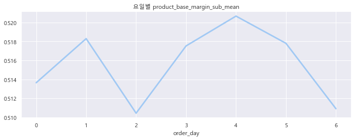

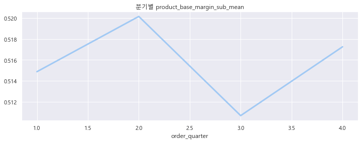

```python
plt.figure(figsize=(12,4));
EW_df.groupby("order_yearmonth").mean().product_base_margin_sub_mean.plot(kind = "line", linewidth = 3);
plt.xticks(rotation=0);
plt.title('연월별 product_base_margin_sub_mean');

plt.figure(figsize=(12,4));
EW_df.groupby("order_year").mean().product_base_margin_sub_mean.plot(kind = "line", linewidth = 3);
plt.xticks(rotation=0);
plt.title('연도별 product_base_margin_sub_mean');

plt.figure(figsize=(12,4));
EW_df.groupby("order_month").mean().product_base_margin_sub_mean.plot(kind = "line", linewidth = 3);
plt.xticks(rotation=0);
plt.title('월별 product_base_margin_sub_mean');

plt.figure(figsize=(12,4));
EW_df.groupby("order_day").mean().product_base_margin_sub_mean.plot(kind = "line", linewidth = 3);
plt.xticks(rotation=0);
plt.title('요일별 product_base_margin_sub_mean');

plt.figure(figsize=(12,4));
EW_df.groupby("order_quarter").mean().product_base_margin_sub_mean.plot(kind = "line", linewidth = 3);
plt.xticks(rotation=0);

plt.title('분기별 product_base_margin_sub_mean');
```

- 마진율이 분기별 기준으로 봤을 때 할인율이랑 딱 똑같은 양상을 보입니다.
- 할인율이 높으면 마진율이 낮아야 하는 게 일반적인 경우입니다.

## Customer Segment 생성

```python
len(EW_df['customer_name'].unique())
```

```
782
```

```python
EW_df['Customer Information'] = EW_df['customer_name'].str.cat(EW_df[['city']], sep=' - ')
EW_df['Customer Information']
```

```
2203           Cathy Armstrong - Pueblo West
1268                Ivan Riston - Kingsville
3634    Nichelle Ronsdale - Glendale Heights
5381                Eudokia Nartin - Leander
857               Emily Grady - Spanish Fork
                        ...
1982         Christopher Nartinez - Thornton
2121              Aaron Smayling - Smithtown
5520                 Nichelle Tran - Crofton
3046                      Sam Craven - Evans
2915                  Nichael Baige - Bangor
Name: Customer Information, Length: 5500, dtype: object
```

```python
len(EW_df['Customer Information'].unique())
```

```
1987
```

같은 이름인데 다른 도시로 배송하면 다른 Customer이라 추청합니다.

고객 가치 분석하기 위해 RFM 모형을 생성해봅니다. 고객의 최근성 `Recency`, 고객의 구매빈도 `Frequency`, 고객의 구매금액 `Monetary` 세 가지 변수를 측정한 지표를 바탕으로 고객이 기업에 가져다 주는 수익에 얼마나 기여하는지 판단할 수 있는 모형입니다.

```python
# R = Recency 구매최근성
df_recency = EW_df.groupby(by='Customer Information',
                        as_index=False)['order_date'].max()
df_recency.columns = ['Customer Information', 'order_date']
recent_date = df_recency['order_date'].max()
df_recency['Recency'] = df_recency['order_date'].apply(
    lambda x: (recent_date - x).days)
df_recency.head()
```

|  | Customer Information | order_date | Recency |
| --- | --- | --- | --- |
| 0 | Aaron Mawkins - Bedford | 2018-12-23 | 371 |
| 1 | Aaron Mawkins - Camden | 2018-12-23 | 371 |
| 2 | Aaron Mawkins - Cranston | 2018-02-22 | 675 |
| 3 | Aaron Mawkins - Fall River | 2018-10-28 | 427 |
| 4 | Aaron Mawkins - Pennsauken | 2017-10-02 | 818 |

```python
# F = Frequency 구매빈도
frequency_df = EW_df.drop_duplicates().groupby(
    by=['Customer Information'], as_index=False)['order_date'].count()
frequency_df.columns = ['Customer Information', 'Frequency']
frequency_df.head()
```

|  | Customer Information | Frequency |
| --- | --- | --- |
| 0 | Aaron Mawkins - Bedford | 1 |
| 1 | Aaron Mawkins - Camden | 1 |
| 2 | Aaron Mawkins - Cranston | 1 |
| 3 | Aaron Mawkins - Fall River | 1 |
| 4 | Aaron Mawkins - Pennsauken | 1 |

```python
# M = Monetary 구매금액
monetary_df = EW_df.groupby(by='Customer Information', as_index=False)['profit'].sum()
monetary_df.columns = ['Customer Information', 'Monetary']
monetary_df.head()
```

|  | Customer Information | Monetary |
| --- | --- | --- |
| 0 | Aaron Mawkins - Bedford | -317.478800 |
| 1 | Aaron Mawkins - Camden | -693.229195 |
| 2 | Aaron Mawkins - Cranston | 23.121200 |
| 3 | Aaron Mawkins - Fall River | 79.341200 |
| 4 | Aaron Mawkins - Pennsauken | 193.121200 |

```python
# 세 가지 dataframe을 merge하기
rf_df = df_recency.merge(frequency_df, on='Customer Information')
rfm_df = rf_df.merge(monetary_df, on='Customer Information')
rfm_df.head()
```

|  | Customer Information | order_date | Recency | Frequency | Monetary |
| --- | --- | --- | --- | --- | --- |
| 0 | Aaron Mawkins - Bedford | 2018-12-23 | 371 | 1 | -317.478800 |
| 1 | Aaron Mawkins - Camden | 2018-12-23 | 371 | 1 | -693.229195 |
| 2 | Aaron Mawkins - Cranston | 2018-02-22 | 675 | 1 | 23.121200 |
| 3 | Aaron Mawkins - Fall River | 2018-10-28 | 427 | 1 | 79.341200 |
| 4 | Aaron Mawkins - Pennsauken | 2017-10-02 | 818 | 1 | 193.121200 |

```python
#R, F, M로 고객세분화 하기
rfm_df['R_rank'] = rfm_df['Recency'].rank(ascending=False)
rfm_df['F_rank'] = rfm_df['Frequency'].rank(ascending=True)
rfm_df['M_rank'] = rfm_df['Monetary'].rank(ascending=True)

#Normalizing the rank
rfm_df['R_rank_norm'] = (rfm_df['R_rank']/rfm_df['R_rank'].max())*100
rfm_df['F_rank_norm'] = (rfm_df['F_rank']/rfm_df['F_rank'].max())*100
rfm_df['M_rank_norm'] = (rfm_df['F_rank']/rfm_df['M_rank'].max())*100

rfm_df.drop(columns=['R_rank', 'F_rank', 'M_rank'], inplace=True)

rfm_df.head()
```

|  | Customer Information | order_date | Recency | Frequency | Monetary | R_rank_norm | F_rank_norm | M_rank_norm |
| --- | --- | --- | --- | --- | --- | --- | --- | --- |
| 0 | Aaron Mawkins - Bedford | 2018-12-23 | 371 | 1 | -317.478800 | 56.894816 | 18.696527 | 18.696527 |
| 1 | Aaron Mawkins - Camden | 2018-12-23 | 371 | 1 | -693.229195 | 56.894816 | 18.696527 | 18.696527 |
| 2 | Aaron Mawkins - Cranston | 2018-02-22 | 675 | 1 | 23.121200 | 34.398591 | 18.696527 | 18.696527 |
| 3 | Aaron Mawkins - Fall River | 2018-10-28 | 427 | 1 | 79.341200 | 51.937594 | 18.696527 | 18.696527 |
| 4 | Aaron Mawkins - Pennsauken | 2017-10-02 | 818 | 1 | 193.121200 | 25.012582 | 18.696527 | 18.696527 |

```python
#RFM 공식: 0.15*Recency score + 0.28*Frequency score + 0.57 *Monetary score 적용

rfm_df['RFM_Score'] = 0.15*rfm_df['R_rank_norm']+0.28 * \
    rfm_df['F_rank_norm']+0.57*rfm_df['M_rank_norm']
rfm_df['RFM_Score'] *= 0.05
rfm_df = rfm_df.round(2)
rfm_df[['Customer Information', 'RFM_Score']].head(7)
```

|  | Customer Information | RFM_Score |
| --- | --- | --- |
| 0 | Aaron Mawkins - Bedford | 1.22 |
| 1 | Aaron Mawkins - Camden | 1.22 |
| 2 | Aaron Mawkins - Cranston | 1.05 |
| 3 | Aaron Mawkins - Fall River | 1.18 |
| 4 | Aaron Mawkins - Pennsauken | 0.98 |
| 5 | Aaron Mawkins - Roselle | 0.85 |
| 6 | Aaron Mawkins - San Gabriel | 2.25 |

```python
# RFM score > 4.5     : Top Customer
# 4.5 > RFM score > 4 : High Value Customer
# 4 > RFM score >3    : Medium value customer
# 3 > RFM score > 1.6 : Low-value customer
# RFM score < 1.6     : Lost Customer


rfm_df["CustomerSegment"] = np.where(rfm_df['RFM_Score'] >
                                      4.5, "Top Customers",
                                      (np.where(
                                        rfm_df['RFM_Score'] > 4,
                                        "High Value Customers",
                                        (np.where(
    rfm_df['RFM_Score'] > 3,
                             "Medium Value Customers",
                             np.where(rfm_df['RFM_Score'] > 1.6,
                            'Low Value Customers', 'Lost Customers'))))))
rfm_df[['Customer Information', 'RFM_Score', 'CustomerSegment']].head(20)
```

|  | Customer Information | RFM_Score | CustomerSegment |
| --- | --- | --- | --- |
| 0 | Aaron Mawkins - Bedford | 1.22 | Lost Customers |
| 1 | Aaron Mawkins - Camden | 1.22 | Lost Customers |
| 2 | Aaron Mawkins - Cranston | 1.05 | Lost Customers |
| 3 | Aaron Mawkins - Fall River | 1.18 | Lost Customers |
| 4 | Aaron Mawkins - Pennsauken | 0.98 | Lost Customers |
| 5 | Aaron Mawkins - Roselle | 0.85 | Lost Customers |
| 6 | Aaron Mawkins - San Gabriel | 2.25 | Low Value Customers |
| 7 | Aaron Smayling - Smithtown | 3.88 | Medium Value Customers |
| 8 | Aaron Vergman - Addison | 1.10 | Lost Customers |
| 9 | Aaron Vergman - Anacortes | 3.79 | Medium Value Customers |
| 10 | Adam Mart - Laguna Hills | 2.96 | Low Value Customers |
| 11 | Adam Mart - Laguna Niguel | 3.56 | Medium Value Customers |
| 12 | Adam Mart - Lake Elsinore | 3.71 | Medium Value Customers |
| 13 | Adam Mart - Lake Forest | 3.34 | Medium Value Customers |
| 14 | Adam Mart - Lakewood | 3.52 | Medium Value Customers |
| 15 | Adam Shillingsburg - Eugene | 1.14 | Lost Customers |
| 16 | Adam Shillingsburg - Grants Pass | 4.13 | High Value Customers |
| 17 | Adam Shillingsburg - Gresham | 1.99 | Low Value Customers |
| 18 | Adam Vellavance - Great Falls | 2.23 | Low Value Customers |
| 19 | Adam Vellavance - Helena | 4.25 | High Value Customers |

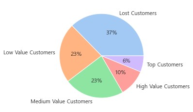

```python
# visualize
plt.pie(rfm_df.CustomerSegment.value_counts(),
        labels=rfm_df.CustomerSegment.value_counts().index,
        autopct='%.0f%%')
plt.show()
```

```python
rfm_df2 = rfm_df.groupby(by='CustomerSegment').agg(['sum','count'])['Monetary'].reset_index()
rfm_df2 = rfm_df2.rename(columns={'sum':'Total Revenue','count':'Total Customers'}).sort_values('Total Revenue',ascending=False)
rfm_df2
```

|  | CustomerSegment | Total Revenue | Total Customers |
| --- | --- | --- | --- |
| 3 | Medium Value Customers | 335766.52 | 457 |
| 0 | High Value Customers | 312592.94 | 208 |
| 2 | Low Value Customers | 164742.69 | 457 |
| 4 | Top Customers | 159998.74 | 123 |
| 1 | Lost Customers | 125057.92 | 742 |

```python
125057.92	/rfm_df2['Total Revenue'].sum()
```

```
0.11387963094336057
```

  → 마일리지 제도 활용 추천